# Projekt_1

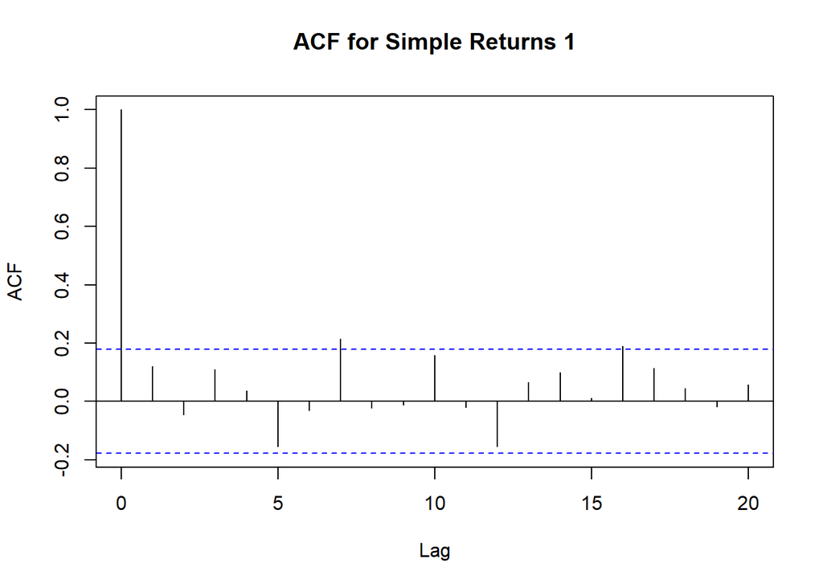

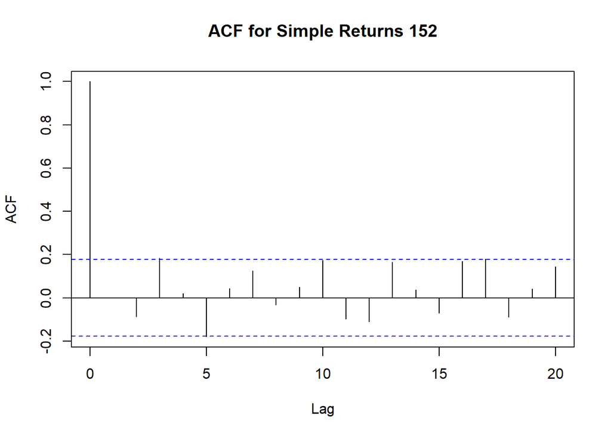

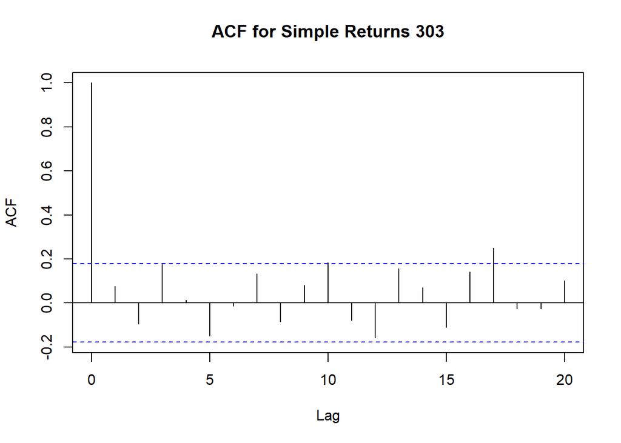

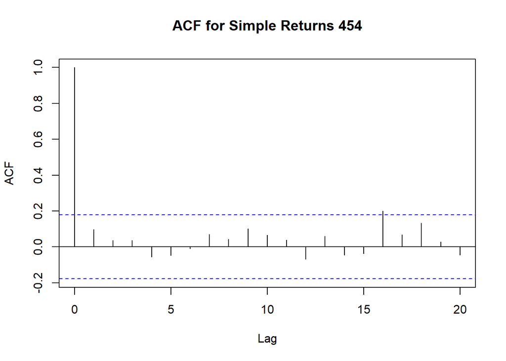

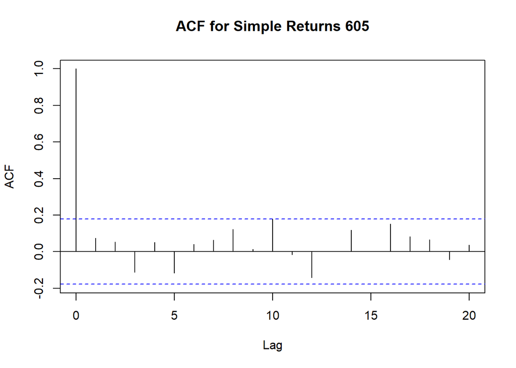

```
## $`02`
##
## Autocorrelations of series 'row_returns', by lag
##
##      0      1      2      3      4      5      6      7      8      9     10
##  1.000  0.121 -0.047  0.110  0.037 -0.156 -0.031  0.215 -0.023 -0.013  0.157
##     11     12     13     14     15     16     17     18     19     20
## -0.020 -0.155  0.066  0.099  0.010  0.190  0.113  0.045 -0.018  0.056
##
## $`07`
##
## Autocorrelations of series 'row_returns', by lag
##
##      0      1      2      3      4      5      6      7      8      9     10
##  1.000  0.002 -0.088  0.184  0.021 -0.180  0.042  0.125 -0.033  0.049  0.172
##     11     12     13     14     15     16     17     18     19     20
## -0.097 -0.111  0.165  0.036 -0.071  0.168  0.180 -0.090  0.040  0.143
##
## $`13`
##
## Autocorrelations of series 'row_returns', by lag
##
##      0      1      2      3      4      5      6      7      8      9     10
##  1.000  0.075 -0.097  0.181  0.014 -0.151 -0.014  0.134 -0.085  0.081  0.182
##     11     12     13     14     15     16     17     18     19     20
## -0.080 -0.158  0.155  0.070 -0.111  0.141  0.249 -0.026 -0.027  0.102
##
## $`21`
##
## Autocorrelations of series 'row_returns', by lag
##
##      0      1      2      3      4      5      6      7      8      9     10
##  1.000  0.097  0.036  0.035 -0.057 -0.047 -0.010  0.070  0.042  0.102  0.065
##     11     12     13     14     15     16     17     18     19     20
##  0.039 -0.069  0.059 -0.046 -0.038  0.200  0.069  0.132  0.027 -0.046
##
## $`28`
##
## Autocorrelations of series 'row_returns', by lag
##
##      0      1      2      3      4      5      6      7      8      9     10
##  1.000  0.073  0.052 -0.114  0.051 -0.117  0.040  0.063  0.123  0.012  0.179
##     11     12     13     14     15     16     17     18     19     20
## -0.016 -0.142  0.000  0.119  0.000  0.151  0.082  0.066 -0.043  0.036
```

```r
# Funkcja do rysowania wykresu ACF dla każdego rzędu
plot_acf_for_each_row <- function(df, title_prefix = "ACF for Row") {
  apply(df, 1, function(row_returns) {
    # Usuwanie NA z wierszy
    row_returns <- as.numeric(na.omit(row_returns))

    # Rysowanie wykresu ACF
    acf(row_returns, main = paste(title_prefix, which(df == row_returns), sep = " "))
  })
}

# Rysowanie wykresu ACF dla stóp zwrotu zwykłych
plot_acf_for_each_row(stopy_zwykle, title_prefix = "ACF for Simple Returns")
```

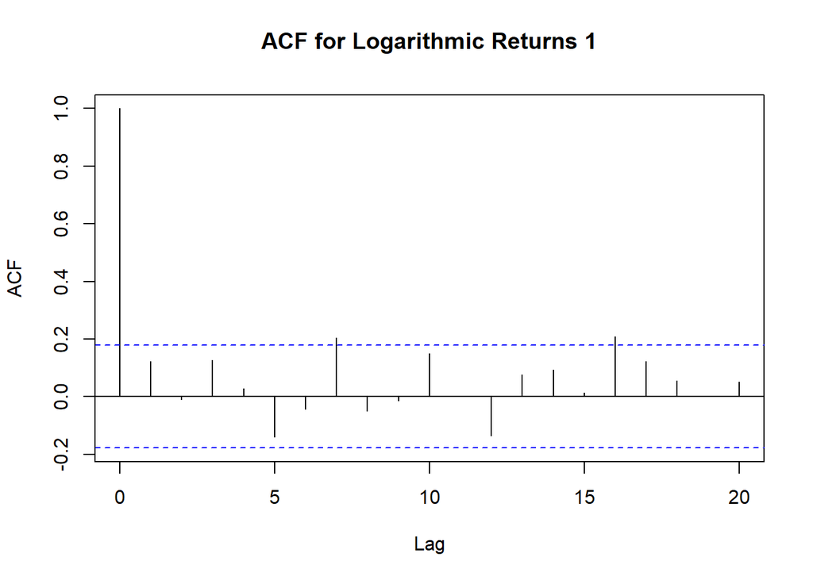

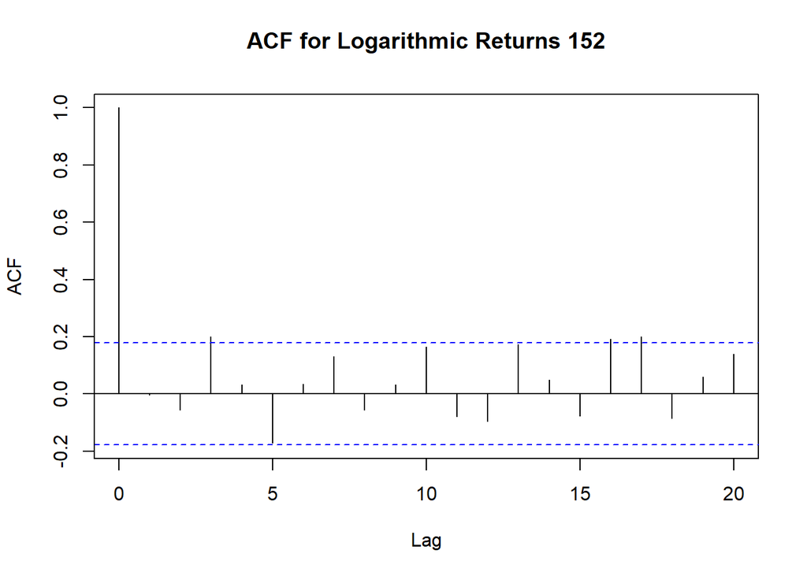

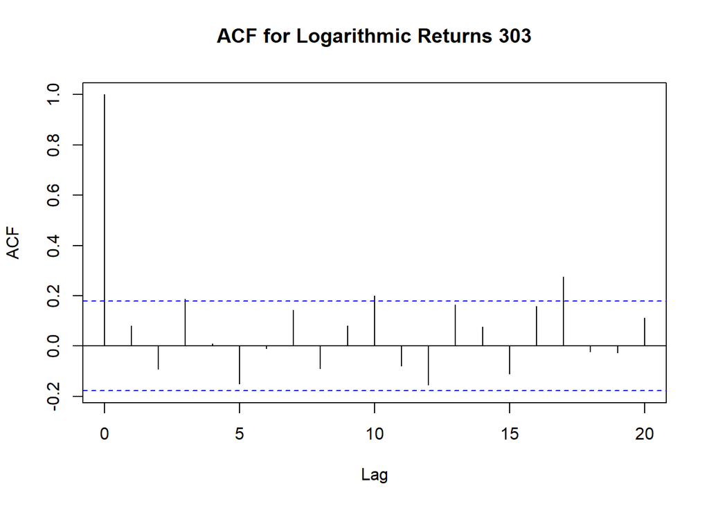

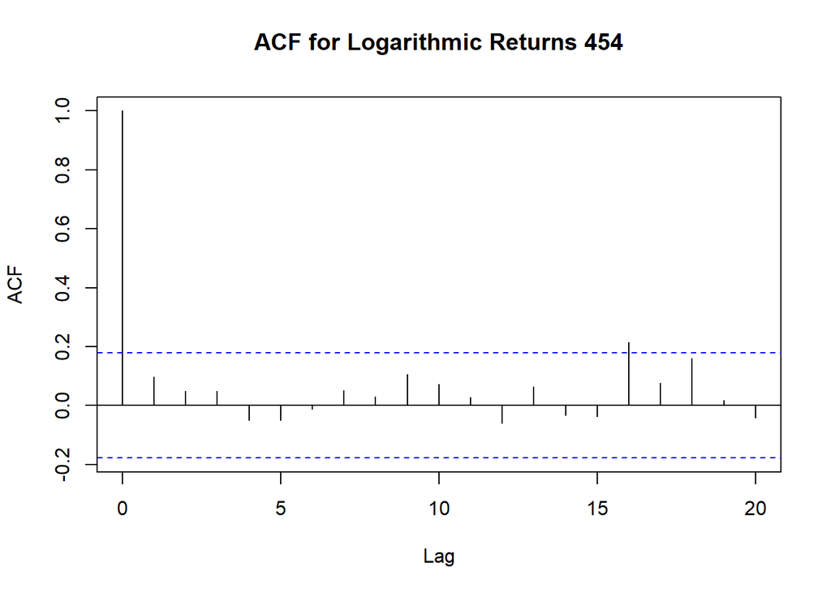

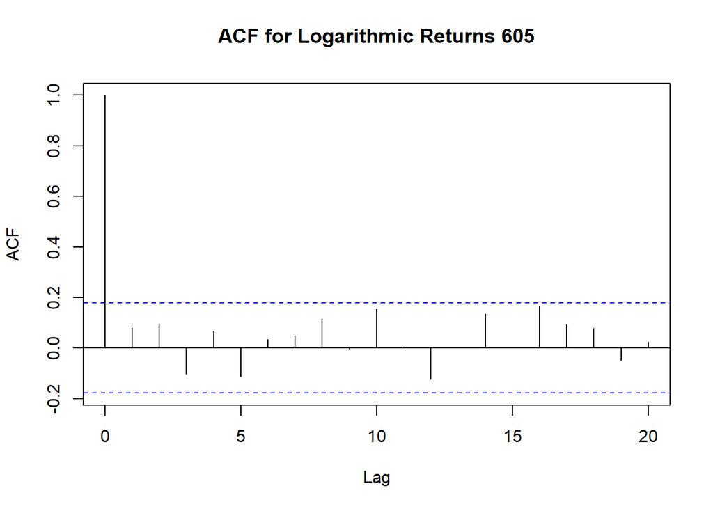

```
## $`02`
##
## Autocorrelations of series 'row_returns', by lag
##
##      0      1      2      3      4      5      6      7      8      9     10
##  1.000  0.123 -0.010  0.126  0.028 -0.139 -0.043  0.204 -0.050 -0.014  0.150
##     11     12     13     14     15     16     17     18     19     20
##  0.000 -0.137  0.075  0.093  0.013  0.208  0.122  0.055  0.004  0.052
##
## $`07`
##
## Autocorrelations of series 'row_returns', by lag
##
##      0      1      2      3      4      5      6      7      8      9     10
##  1.000 -0.003 -0.057  0.199  0.031 -0.171  0.033  0.130 -0.057  0.031  0.164
##     11     12     13     14     15     16     17     18     19     20
## -0.078 -0.096  0.172  0.049 -0.076  0.191  0.199 -0.086  0.059  0.138
##
## $`13`
##
## Autocorrelations of series 'row_returns', by lag
##
##      0      1      2      3      4      5      6      7      8      9     10
##  1.000  0.079 -0.091  0.186  0.008 -0.150 -0.009  0.142 -0.091  0.079  0.199
##     11     12     13     14     15     16     17     18     19     20
## -0.079 -0.154  0.164  0.076 -0.112  0.157  0.275 -0.022 -0.027  0.112
##
## $`21`
##
## Autocorrelations of series 'row_returns', by lag
##
##      0      1      2      3      4      5      6      7      8      9     10
##  1.000  0.096  0.049  0.049 -0.050 -0.049 -0.012  0.050  0.030  0.105  0.072
##     11     12     13     14     15     16     17     18     19     20
##  0.028 -0.060  0.064 -0.033 -0.038  0.215  0.075  0.160  0.018 -0.041
##
## $`28`
##
## Autocorrelations of series 'row_returns', by lag
##
##      0      1      2      3      4      5      6      7      8      9     10
##  1.000  0.079  0.097 -0.102  0.065 -0.113  0.035  0.049  0.116 -0.003  0.153
##     11     12     13     14     15     16     17     18     19     20
##  0.004 -0.124  0.000  0.135  0.001  0.164  0.093  0.079 -0.048  0.023
```

```r
# Rysowanie wykresu ACF dla stóp zwrotu logarytmicznych
plot_acf_for_each_row(stopy_log, title_prefix = "ACF for Logarithmic Returns")
```

**Autokorelacja dla pierwszego opóźnienia (lagu):** mierzy, w jakim stopniu obecna stopa zwrotu jest skorelowana z poprzednią.  
**P-wartość testu Ljunga-Boxa:** sprawdza, czy w szeregu czasowym występuje istotna autokorelacja na różnych opóźnieniach (zazwyczaj 10 lagów). Jeśli p-wartość jest niższa niż 0.05, odrzucamy hipotezę zerową o braku autokorelacji.

Stopy zwrotu logarytmiczne wykazują nieco wyższe autokorelacje na pierwszym lag, co może sugerować nieco większe zależności między kolejnymi okresami w porównaniu do stóp zwykłych. Jednak większość serii (zarówno zwykłych, jak i logarytmicznych) nie wykazuje istotnych autokorelacji na poziomie wielu lagów, o czym świadczą wysokie p-wartości testu Ljunga-Boxa. Jedynie w jednej serii logarytmicznych stóp zwrotu możemy zauważyć istotne zależności w kilku lagach, co może sugerować potencjalne wzorce zależności w danych.

```r
# Funkcja do porównania wartości oczekiwanych (średnich) oraz wariancji
compare_means_variances <- function(df) {
  n <- nrow(df)
  t_test_matrix <- matrix(NA, n, n)
  var_test_matrix <- matrix(NA, n, n)

  for (i in 1:n) {
    for (j in 1:n) {
      if (i != j) {
        t_test_result <- t.test(unlist(df[i, ]), unlist(df[j, ]))
        var_test_result <- var.test(unlist(df[i, ]), unlist(df[j, ]))

        t_test_matrix[i, j] <- t_test_result$p.value
        var_test_matrix[i, j] <- var_test_result$p.value
      }
    }
  }
  t_test_df <- as.data.frame(t_test_matrix)
  var_test_df <- as.data.frame(var_test_matrix)

  return(list(
    Mean = t_test_df,
    Variance = var_test_df
  ))
}

# Przeprowadzenie testów dla stóp zwrotu
comp_z <- compare_means_variances(stopy_zwykle)
comp_l <- compare_means_variances(stopy_log)

# Wyniki dla stóp zwykłych
print(comp_z$Mean)
```

```
##          V1        V2        V3        V4        V5
## 1        NA 0.9251751 0.9285202 0.9659839 0.9654988
## 2 0.9251751        NA 0.9965527 0.9588876 0.9598994
## 3 0.9285202 0.9965527        NA 0.9622929 0.9632835
## 4 0.9659839 0.9588876 0.9622929        NA 0.9992673
## 5 0.9654988 0.9598994 0.9632835 0.9992673        NA
```

```r
print(comp_z$Variance)
```

```
##          V1        V2        V3        V4        V5
## 1        NA 0.6077037 0.6409013 0.8611124 0.7381218
## 2 0.6077037        NA 0.9625622 0.7350171 0.8578776
## 3 0.6409013 0.9625622        NA 0.7706457 0.8948733
## 4 0.8611124 0.7350171 0.7706457        NA 0.8733515
## 5 0.7381218 0.8578776 0.8948733 0.8733515        NA
```

```r
# Wyniki dla stóp logarytmicznych
print(comp_l$Mean)
```

```
##          V1        V2        V3        V4        V5
## 1        NA 0.9748809 0.9662802 0.9786255 0.9910268
## 2 0.9748809        NA 0.9919783 0.9956688 0.9839417
## 3 0.9662802 0.9919783        NA 0.9873706 0.9755887
## 4 0.9786255 0.9956688 0.9873706        NA 0.9878957
## 5 0.9910268 0.9839417 0.9755887 0.9878957        NA
```

```r
print(comp_l$Variance)
```

```
##          V1        V2        V3        V4        V5
## 1        NA 0.4286720 0.5804548 0.8590169 0.7033486
## 2 0.4286720        NA 0.8111336 0.5392018 0.6811308
## 3 0.5804548 0.8111336        NA 0.7075329 0.8634439
## 4 0.8590169 0.5392018 0.7075329        NA 0.8389733
## 5 0.7033486 0.6811308 0.8634439 0.8389733        NA
```

Zarówno dla stóp zwrotu zwykłych, jak i logarytmicznych, testy porównujące średnie oraz wariancje wskazują na brak istotnych statystycznie różnic między seriami danych. Wszystkie p-wartości przekraczają próg istotności 0.05, co sugeruje, że poszczególne serie danych mają podobne średnie i wariancje.

**Podsumowanie:** W ramach przeprowadzonego projektu zbadano charakterystykę stóp zwrotu zarówno zwykłych, jak i logarytmicznych. Celem analizy była ocena autokorelacji, testowanie wartości oczekiwanych (średnich) i wariancji, a także weryfikacja istotności statystycznej tych różnic przy użyciu szeregu testów statystycznych.